# Лабораторная работа № 5

Построение графиков в Julia

Дагделен Зейнап Реджеповна

1132234052@rudn.ru

Российский университет дружбы народов

2026-10-30

# Информация

## Докладчик

- Дагделен Зейнап Реджеповна
- студентка НКНбд-01-23
- Российский университет дружбы народов им. П. Лумумбы
- 1132234052@rudn.ru

# Введение

## Цель и задачи

- **Цель:** Освоить синтаксис языка Julia для построения графиков с помощью пакета `Plots.jl`.
- **Инструменты:**
  - Пакет `Plots.jl` (основной инструмент).
  - Бэкенды: `gr()`, `pyplot()`, `plotly()`, `unicodeplots()`.
  - Пакеты для статистики: `Statistics`, `Distributions`.

# Теоретическая часть

## Базовые функции: `plot()` и `scatter()`

1. **plot(x, y)** — построение линейного графика (соединяет точки линиями). 2) **scatter(x, y)** — построение точечного графика (только маркеры, без линий). 3)**Поэлементные операции:** В Julia для применения функции к массиву используется точка (`.`): `x.^2`, `exp.(x)`, `sin.(x)`.

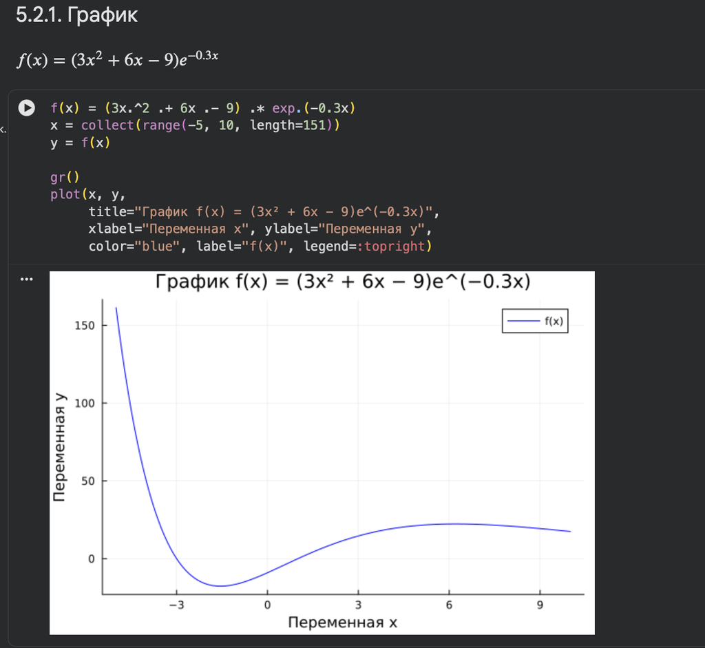

## Настройка осей и легенды

- **`xlabel`, `ylabel`** — подписи осей, **`title`** — заголовок графика, **`label`** — текст в легенде., **`legend`** — позиция легенды (например, `:topright`), **`color`** — цвет линии или маркера.

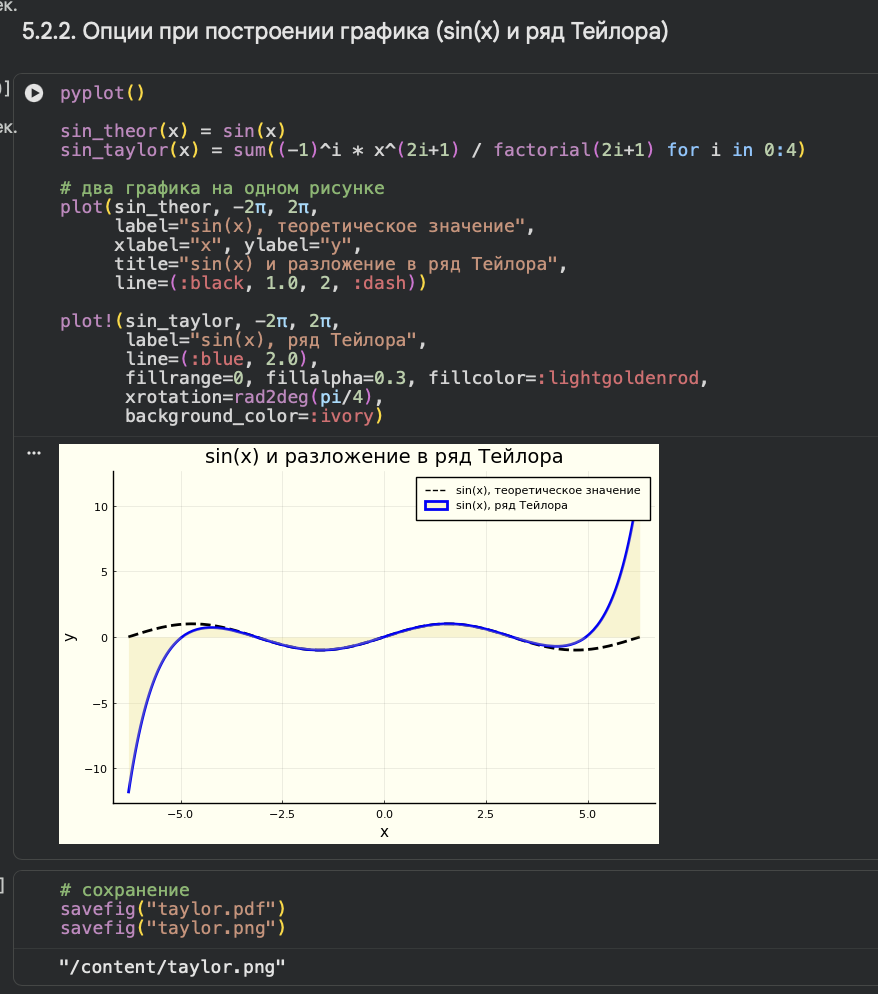

## Комбинирование графиков

- **plot!(…)** — добавить график на уже существующий (восклицательный знак означает изменение *in-place*). **layout** — создание сетки подграфиков.

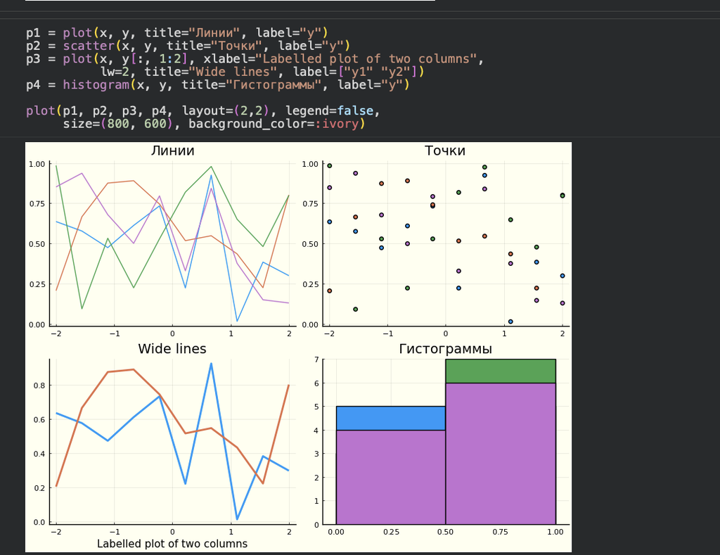

## 3D-графики и поверхности

- **scatter(x, y, z)** — 3D точечный график. **surface(x, y, f)** — поверхность. **linetype=:wireframe** — каркасный вид поверхности.

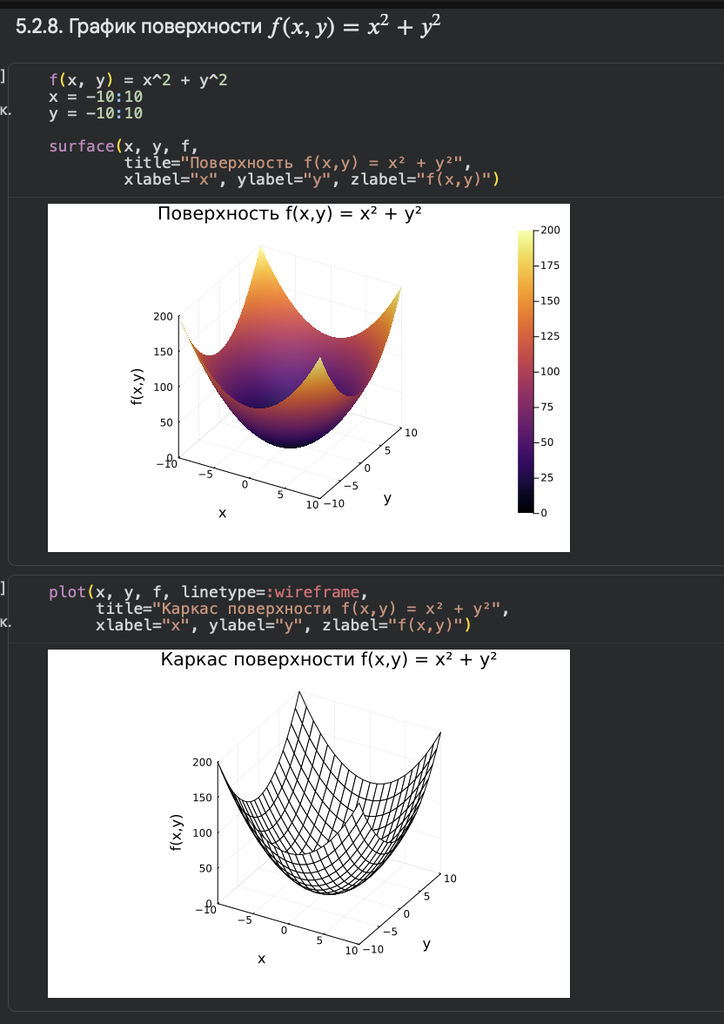

## Параметрические кривые

- Позволяют задать координаты как функции от параметра $t$. В коде мы создаем массив $t$ (например, range(0, 2π, length=500)).
- Вычисляем $x = \sin.(t)$ и $y = \sin.(2t)$. Результат — фигура Лиссажу на плоскости.

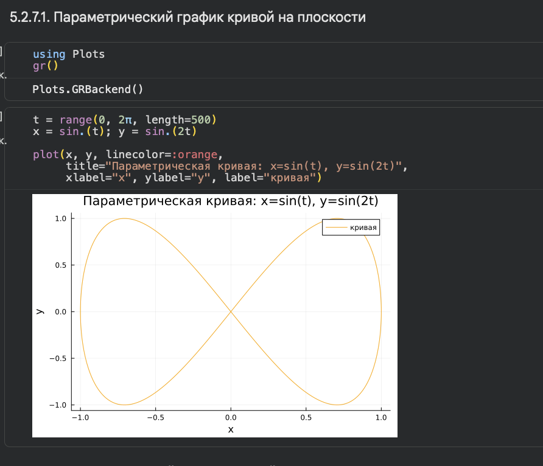

## Статистика и распределения

- **histogram(data)** — гистограмма (автоматически разбивает данные на интервалы). Пакет `Distributions` позволяет генерировать выборки: rand(Normal(μ, σ), N). Пакет `Statistics` используется для расчета средних и отклонений.

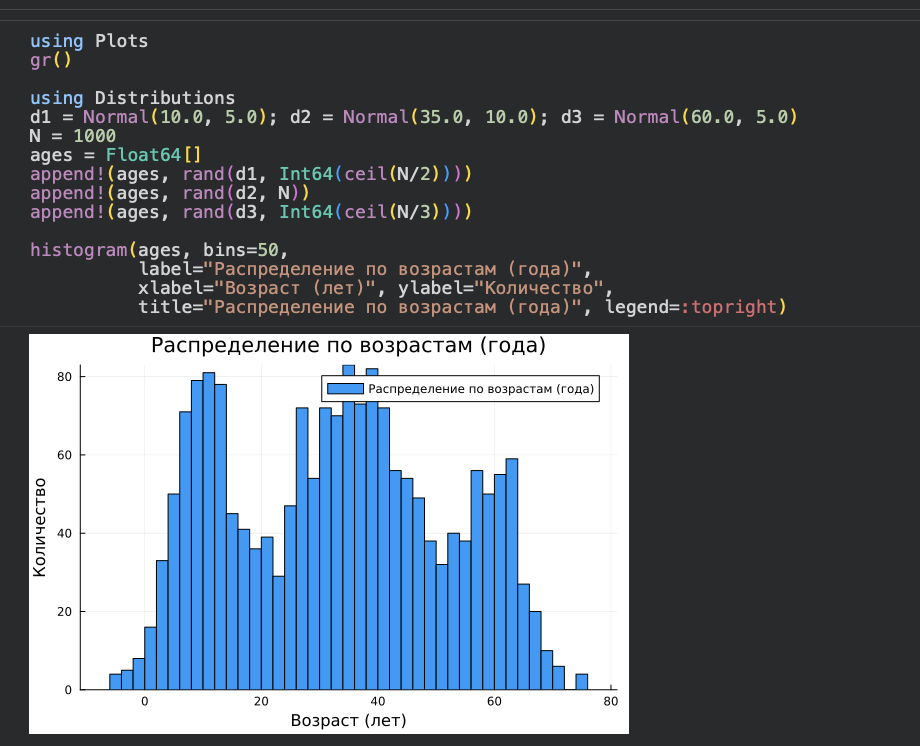

## Погрешности (Errorbars)

- Параметр **err** в функции `plot()` добавляет вертикальные “усы” погрешностей. Используется для визуализации доверительных интервалов. В коде мы вычисляли погрешность как $1.96 \cdot \text{std} / \sqrt{n}$.

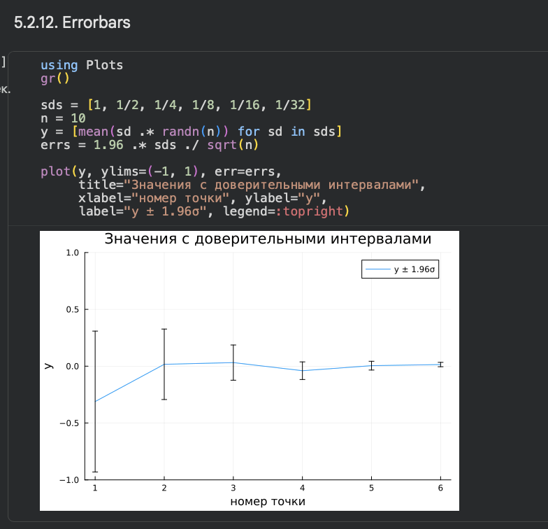

# Выводы

## Заключение

- Освоен базовый синтаксис `Plots.jl` для 2D и 3D графиков.
- Изучено построение графиков с несколькими осями и наложение слоев.
- Выполнены задания на оформление, кастомизацию и статистическую визуализацию.
- `Plots.jl` позволяет быстро переключаться между разными движками отрисовки (`gr`, `pyplot`, `plotly`) без изменения основного кода.